# MATH523_Assignment1

Caiwei Xiong

09/02/2021

Load the data africa from the faraway library:

```r
library(faraway)
data("africa")
attach(africa)
head(africa)
```

|  | miltcoup | oligarchy | pollib | parties | pctvote | popn | size | numelec | numregim |
| --- | --- | --- | --- | --- | --- | --- | --- | --- | --- |
| Angola | 0 | 0 | 2 | 38 | NA | 9.7 | 1247 | 0 | 1 |
| Benin | 5 | 7 | 1 | 34 | 45.68 | 4.6 | 113 | 8 | 3 |
| Botswana | 0 | 0 | NA | 7 | 20.30 | 1.2 | 582 | 5 | 1 |
| Burkina | 6 | 13 | 2 | 62 | 17.50 | 8.8 | 274 | 5 | 3 |
| Burundi | 2 | 13 | 2 | 10 | 34.39 | 5.3 | 28 | 3 | 3 |
| Cameroon | 0 | 0 | 2 | 34 | 30.30 | 11.6 | 475 | 14 | 3 |

#### Question a

```r
canonical_model <- glm(miltcoup ~ oligarchy, data = africa, family = poisson, x = "TRUE")
summary(canonical_model)
```

```
##
## Call:
## glm(formula = miltcoup ~ oligarchy, family = poisson, data = africa,
##     x = "TRUE")
##
## Deviance Residuals:
##     Min       1Q   Median       3Q      Max
## -1.6894  -1.1334  -0.5946   0.4124   2.2838
##
## Coefficients:
##             Estimate Std. Error z value Pr(>|z|)
## (Intercept) -0.44280    0.21321  -2.077   0.0378 *
## oligarchy    0.11761    0.01928   6.100 1.06e-09 ***
## ---
## Signif. codes:  0 '***' 0.001 '**' 0.01 '*' 0.05 '.' 0.1 ' ' 1
##
## (Dispersion parameter for poisson family taken to be 1)
##
##     Null deviance: 93.971  on 46  degrees of freedom
## Residual deviance: 57.048  on 45  degrees of freedom
## AIC: 134.73
##
## Number of Fisher Scoring iterations: 5
```

```r
coef(canonical_model)
```

```
## (Intercept)   oligarchy
##  -0.4427992   0.1176074
```

The oligarchy is clearly significant becuase the $p$-value of the Wald test in oligarchy is 1.06e-09 (i.e. in the summary of the fit, $***$ indicates the oligarchy’s $p$-value). Meanwhile, according to the difference between Null deviance and Residual deviance, the larger of the difference, the worser of the simplier model. And the difference between Null deviance and Residual deviance is huge, which indicates that we could not eliminate the oligarchy for this model.

#### Question b

```r
identity_model <- glm(miltcoup ~ oligarchy, data = africa, family = poisson(link = "identity"))
summary(identity_model)
```

```
##
## Call:
## glm(formula = miltcoup ~ oligarchy, family = poisson(link = "identity"),
##     data = africa)
##
## Deviance Residuals:
##     Min       1Q   Median       3Q      Max
## -1.6919  -0.9101  -0.9045   0.7402   1.8016
##
## Coefficients:
##             Estimate Std. Error z value Pr(>|z|)
## (Intercept)  0.41414    0.12701   3.261  0.00111 **
## oligarchy    0.22266    0.03789   5.877 4.19e-09 ***
## ---
## Signif. codes:  0 '***' 0.001 '**' 0.01 '*' 0.05 '.' 0.1 ' ' 1
##
## (Dispersion parameter for poisson family taken to be 1)
##
##     Null deviance: 93.971  on 46  degrees of freedom
## Residual deviance: 50.904  on 45  degrees of freedom
## AIC: 128.58
##
## Number of Fisher Scoring iterations: 8
```

```r
coef(identity_model)
```

```
## (Intercept)   oligarchy
##   0.4141384   0.2226579
```

The oligarchy is clearly significant becuase the $p$-value of the Wald test in oligarchy is 4.19e-09 (i.e. in the summary of the fit, $***$ indicates the oligarchy’s $p$-value). Meanwhile, according to the difference between Null deviance and Residual deviance, the larger of the difference, the worser of the simplier model. And the difference between Null deviance and Residual deviance is huge, which indicates that we could not eliminate the oligarchy for this model.

#### Question c

```r
linear_regression_model <- lm(miltcoup ~ oligarchy)
summary(linear_regression_model)
```

```
##
## Call:
## lm(formula = miltcoup ~ oligarchy)
##
## Residuals:
##     Min      1Q  Median      3Q     Max
## -2.5023 -0.5202 -0.5202  0.5852  3.0882
##
## Coefficients:
##             Estimate Std. Error t value Pr(>|t|)
## (Intercept)  0.52019    0.23928   2.174    0.035 *
## oligarchy    0.19881    0.03313   6.000 3.12e-07 ***
## ---
## Signif. codes:  0 '***' 0.001 '**' 0.01 '*' 0.05 '.' 0.1 ' ' 1
##
## Residual standard error: 1.293 on 45 degrees of freedom
## Multiple R-squared:  0.4444, Adjusted R-squared:  0.4321
## F-statistic:    36 on 1 and 45 DF,  p-value: 3.122e-07
```

```r
coef(linear_regression_model)
```

```
## (Intercept)   oligarchy
##   0.5201913   0.1988087
```

The oligarchy is clearly significant becuase the $p$-value of the Wald test in oligarchy is 3.12e-07 (i.e. in the summary of the fit, $***$ indicates the oligarchy’s $p$-value)

#### Question d

```r
summary(miltcoup)
```

```
##    Min. 1st Qu.  Median    Mean 3rd Qu.    Max.
##   0.000   0.000   1.000   1.404   2.000   6.000
```

```r
summary(oligarchy)
```

```
##    Min. 1st Qu.  Median    Mean 3rd Qu.    Max.
##   0.000   0.000   1.000   4.447   9.000  18.000
```

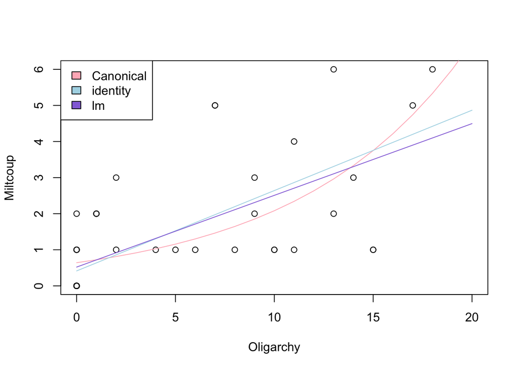

```r
plot(miltcoup ~ oligarchy, africa, xlim=c(0,20),ylab="Miltcoup", xlab="Oligarchy")
x <- seq(0,20,1)
lines(x, exp(coef(canonical_model)[1]+ coef(canonical_model)[2]*x),col="lightpink")
lines(x, (coef(identity_model)[1]+ coef(identity_model)[2]*x), col="lightblue")
lines(x, (coef(linear_regression_model)[1]+coef(linear_regression_model)[2]*x), col="mediumpurple")
legend("topleft", c("Canonical", "identity", "lm"), fill = c("lightpink",
                                              "lightblue","mediumpurple",cex=0.1))
```

#### Question e:

```r
number_canonical <- exp(coef(canonical_model)[1]+ coef(canonical_model)[2]*10)
(number_canonical)
```

```
## (Intercept)
##    2.081886
```

```r
number_identity <- coef(identity_model)[1]+ coef(identity_model)[2]*10
(number_identity)
```

```
## (Intercept)
##    2.640717
```

```r
number_lm <- coef(linear_regression_model)[1]+coef(linear_regression_model)[2]*10
(number_lm)
```

```
## (Intercept)
##    2.508278
```

The expected number of military coups in a country which has been ruled for $10$ years by military oligarchy for GLM model with canonical link is $2.081886$

The expected number of military coups in a country which has been ruled for $10$ years by military oligarchy for GLM model with identity link is $2.640717$

The expected number of military coups in a country which has been ruled for $10$ years by military oligarchy for linear regression model is $2.508278$

#### Question f:

In GLM model with canonical link:
$$expected \ number \ of \ military \ coups = exp\ ( \ \beta_0 + \beta_1 * number \ of \ oligarchy)$$

$$(i.e. exp\ (-0.4427992 + 0.1176074* number \ of \ oligarchy)$$
The expected number of military coups will multiple $exp(\beta_{1} * 10$) per $10$ years. (i.e. multiple $exp ( 0.1176074* 10)= 3.24162$)

In GLM model with identity link:
$$expected \ number \ of \ military \ coups = \beta_0 + \beta_1 \cdot number \ of \ oligarchy$$

$$(i.e. 0.41414 + 0.22266 \cdot number \ of \ oligarchy)$$
The expected number of military coups will add $\beta_{1} \cdot 10$ per $10$ years. (i.e. add $0.22266 \cdot 10 = 2.2266$ )

In Linear regression model:
$$expected \ number\ of\ military \ coups = \beta_0 + \beta_1 \cdot number \ of \ oligarchy$$

$$(i.e. 0.5201913 + 0.1988087 \cdot number \ of\ oligarchy)$$
The expected number of military coups will add $\beta_{1} \cdot 10$ per $10$ years.(i.e. add $0.1988087 \cdot 10 = 1.988087$ )

#### Question g:

```r
AIC(canonical_model)
```

```
## [1] 134.7279
```

```r
AIC(identity_model)
```

```
## [1] 128.5842
```

```r
AIC(linear_regression_model)
```

```
## [1] 161.4563
```

The lower AIC means a model is considered to be closer to the truth. According to the R output, the GLM model with identity link has the lowest AIC. Thus, the GLM model with identity link is the best suited.

#### Question h:

```r
identity_finalmodel <- glm(miltcoup ~ oligarchy+popn+numregim, family = poisson(link = "identity"))
summary(identity_finalmodel)
```

```
##
## Call:
## glm(formula = miltcoup ~ oligarchy + popn + numregim, family = poisson(link = "identity"))
##
## Deviance Residuals:
##     Min       1Q   Median       3Q      Max
## -1.7589  -0.8992  -0.5966   0.7428   1.8135
##
## Coefficients:
##              Estimate Std. Error z value Pr(>|z|)
## (Intercept) -0.027822   0.252495  -0.110    0.912
## oligarchy    0.202039   0.043578   4.636 3.55e-06 ***
## popn        -0.005725   0.004942  -1.159    0.247
## numregim     0.237533   0.135227   1.757    0.079 .
## ---
## Signif. codes:  0 '***' 0.001 '**' 0.01 '*' 0.05 '.' 0.1 ' ' 1
##
## (Dispersion parameter for poisson family taken to be 1)
##
##     Null deviance: 93.971  on 46  degrees of freedom
## Residual deviance: 48.022  on 43  degrees of freedom
## AIC: 129.7
##
## Number of Fisher Scoring iterations: 25
```

For the Poisson GLM with the identity link using oligarchy, popn and numregim as predictors will encounter the step size truncated. The Fisher Scoring Algorithm did not converge. This may due to the identity link could lead the mathematically and computationally convenient. But during the iteration, this may cause some numerical error. In this case, the Fisher Scoring Algorithm may not converge.

```r
log_finalmodel <- glm(miltcoup ~ oligarchy+popn+numregim, family = poisson(link = "log"))
summary(log_finalmodel)
```

```
##
## Call:
## glm(formula = miltcoup ~ oligarchy + popn + numregim, family = poisson(link = "log"))
##
## Deviance Residuals:
##     Min       1Q   Median       3Q      Max
## -1.8494  -1.0686  -0.8104   0.6278   2.2860
##
## Coefficients:
##              Estimate Std. Error z value Pr(>|z|)
## (Intercept) -1.101243   0.498842  -2.208 0.027272 *
## oligarchy    0.094996   0.024614   3.859 0.000114 ***
## popn         0.005513   0.005075   1.086 0.277297
## numregim     0.263318   0.170986   1.540 0.123561
## ---
## Signif. codes:  0 '***' 0.001 '**' 0.01 '*' 0.05 '.' 0.1 ' ' 1
##
## (Dispersion parameter for poisson family taken to be 1)
##
##     Null deviance: 93.971  on 46  degrees of freedom
## Residual deviance: 54.536  on 43  degrees of freedom
## AIC: 136.22
##
## Number of Fisher Scoring iterations: 5
```

The canonical link for the Poisson GLM is log link. In this case, this model is the Poisson GLM with canonical link. The canonical link may not fit well to the date set. But, in using iterative to find the ML estimates, we do not need worry about the possibility of multiple maxima for the log likelihood. In another word, the canonical link could guarantee the convergence of Fisher Scoring Algorithm. Meanwhile, Fisher Scoring Algorithm and Newton-Raphson algorithm are equivalent under canonical link. Under the Newton-Raphson algorithm the convergence to solution is guaranteed (i.e.globally convergent at quadratic rate).

The identity link may cause coeffcients become negative, however, the log link can always constrain the coeffcients positive and sensible for all covariante value.